# Ex33 clusters

PIE2

Tardor 2019-2020

####En el fitxer clusters.csv hi ha dues variables: Cancers i Distancia.

####• Cancers: nombre de càncers detectats en un hospital durant un any.

####• Distancia: distància des de l’hospital a una central nuclear.

####L’objectiu és conèixer si hi ha alguna relació entre la proximitat a la central nuclear i la incidència de càncers. Dieu, en aquest cas, quina és la variable resposta, la variable explicativa i de quin tipus són.

*Entrar dades, paquests, descriptiva…*

```r
#setwd("...")
dd<-read.csv2("../data/clusters.csv")
library(car)
```

**a) Descriptiva: feu una gràfica de les dades.**

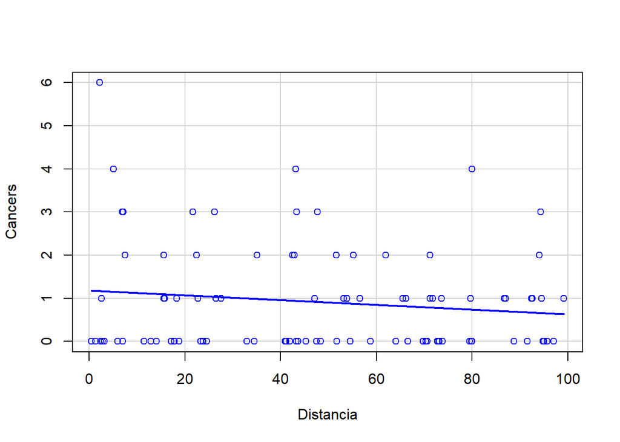

```r
sp(Cancers~Distancia,smooth=F,boxplot=F,dat=dd)
```

**b) Ajusteu el MLG adequat per explicar el nombre de càncers en funció de la distància a la central nuclear. Suposeu que** $Cancers\sim Poisson\left(\mu\right)$ **on** $\mu$ **depèn de la distància seguint la funció:** $\mu=e^{\alpha+\beta\cdot Distancia}.$

*i. Quina família de distribucions i quina funció link heu de considerar?*

*Familia Poisson i link=log*

*ii. La relació entre Cancers i Distancia és significativa amb un nivell del 10%?*

```r
m1<-glm(Cancers~Distancia,family=poisson,data=dd)
#m1<-glm(Cancers~Distancia,family=poisson(link=log),data=dd)
summary(m1)
```

```
##
## Call:
## glm(formula = Cancers ~ Distancia, family = poisson, data = dd)
##
## Deviance Residuals:
##     Min       1Q   Median       3Q      Max
## -1.5504  -1.3491  -1.1553   0.3877   3.1304
##
## Coefficients:
##              Estimate Std. Error z value Pr(>|z|)
## (Intercept)  0.186865   0.188728   0.990   0.3221
## Distancia   -0.006138   0.003667  -1.674   0.0941 .
## ---
## Signif. codes:  0 '***' 0.001 '**' 0.01 '*' 0.05 '.' 0.1 ' ' 1
##
## (Dispersion parameter for poisson family taken to be 1)
##
##     Null deviance: 149.48  on 93  degrees of freedom
## Residual deviance: 146.64  on 92  degrees of freedom
## AIC: 262.41
##
## Number of Fisher Scoring iterations: 5
```

**Test anova, també fet a mà**

```r
Anova(m1)
```

```
## Analysis of Deviance Table (Type II tests)
##
## Response: Cancers
##           LR Chisq Df Pr(>Chisq)
## Distancia   2.8408  1     0.0919 .
## ---
## Signif. codes:  0 '***' 0.001 '**' 0.01 '*' 0.05 '.' 0.1 ' ' 1
```

```r
c("Est.contrast"=(m1$null.deviance-m1$deviance)/1)
```

```
## Est.contrast
##     2.840827
```

*Sí, per molt poc.*

*iii. Valideu el model. Hi ha sobredispersió?*

```r
c("Pearson"=PS<-sum(residuals(m1,type="pearson")^2))
```

```
##  Pearson
## 143.0709
```

```r
c("Par.disp"=PS/m1$df.res)
```

```
## Par.disp
## 1.555119
```

```r
# P value
c("p.valor"=2*min(pchisq(PS,m1$df.res),1-pchisq(PS,m1$df.res)))
```

```
##     p.valor
## 0.001039625
```

```r
# IC
c("IC.inf"=qchisq(0.025,m1$df.res),"IC.sup"=qchisq(0.975,m1$df.res))/m1$df.res
```

```
##    IC.inf    IC.sup
## 0.7321257 1.3089900
```

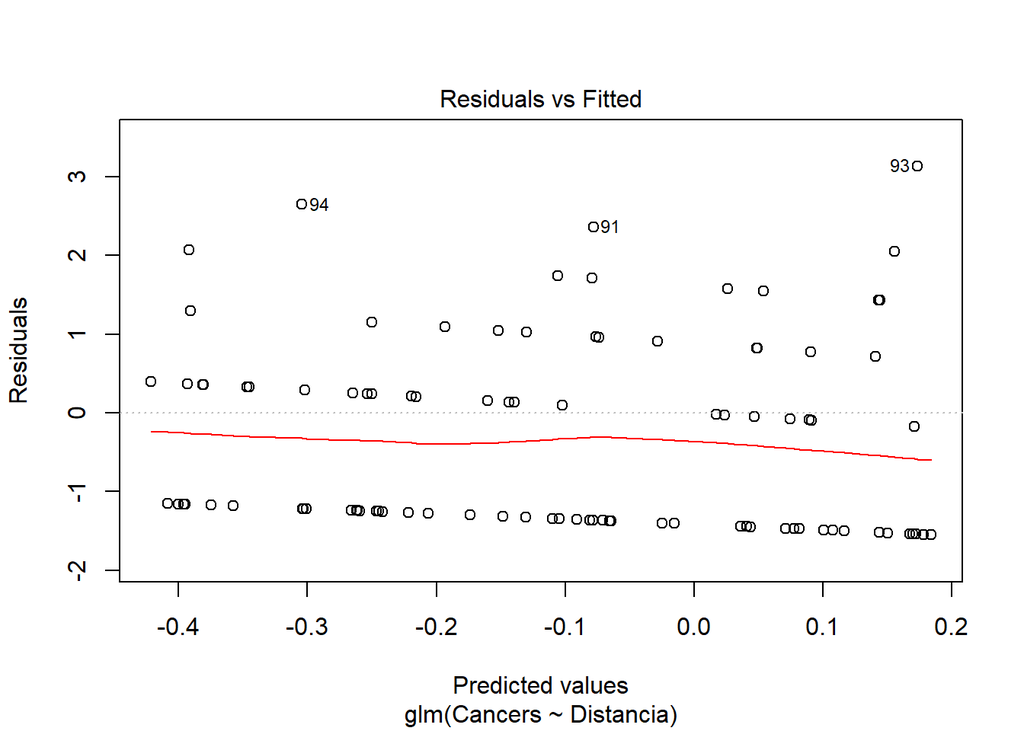

```r
plot(m1,1)
```

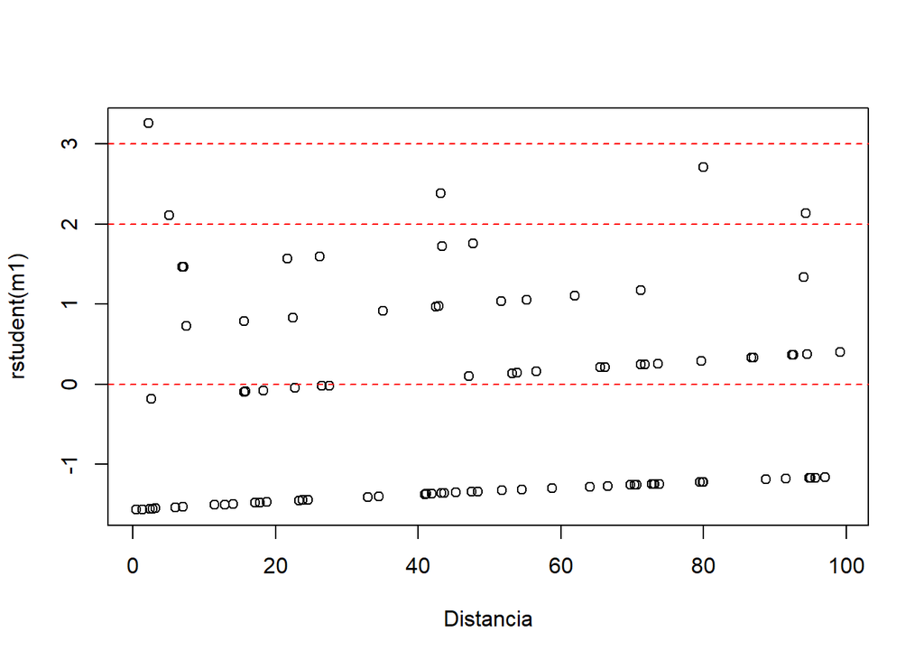

```r
plot(rstudent(m1)~Distancia,dd)
abline(h=c(-3,-2,0,2,3),lty=2,col="red")
```

*Sí hi ha sobre-dispersió. Model no vàlid encara que la gràfica de residuals suert raonablement bé.*

**c) Repetiu l’apartat b) suposant ara que depèn de Distancia seguint la funció:** $\mu=\alpha+\beta\cdot Distancia$.

*i. Quina família de distribucions i quina funció link heu de considerar?*

*Familia Poisson i link=identity*

*ii. La relació entre Cancers i Distancia és significativa amb un nivell del 10%?*

```r
m2<-glm(Cancers~Distancia,family=poisson(link=identity),data=dd)
summary(m2)
```

```
##
## Call:
## glm(formula = Cancers ~ Distancia, family = poisson(link = identity),
##     data = dd)
##
## Deviance Residuals:
##    Min      1Q  Median      3Q     Max
## -1.524  -1.360  -1.149   0.400   3.178
##
## Coefficients:
##              Estimate Std. Error z value Pr(>|z|)
## (Intercept)  1.164341   0.197477   5.896 3.72e-09 ***
## Distancia   -0.005235   0.003248  -1.612    0.107
## ---
## Signif. codes:  0 '***' 0.001 '**' 0.01 '*' 0.05 '.' 0.1 ' ' 1
##
## (Dispersion parameter for poisson family taken to be 1)
##
##     Null deviance: 149.48  on 93  degrees of freedom
## Residual deviance: 146.78  on 92  degrees of freedom
## AIC: 262.54
##
## Number of Fisher Scoring iterations: 5
```

*No és significatiu per molt poc.*

*iii. Valideu el model. Hi ha sobredispersió?*

```r
c("Pearson"=PS<-sum(residuals(m2,type="pearson")^2))
```

```
##  Pearson
## 143.6932
```

```r
c("Par.disp"=PS/m2$df.res)
```

```
## Par.disp
## 1.561883
```

```r
# P value
c("p.valor"=2*min(pchisq(PS,m2$df.res),1-pchisq(PS,m2$df.res)))
```

```
##      p.valor
## 0.0009201392
```

```r
# IC
c("IC.inf"=qchisq(0.025,m2$df.res),"IC.sup"=qchisq(0.975,m2$df.res))/m1$df.res
```

```
##    IC.inf    IC.sup
## 0.7321257 1.3089900
```

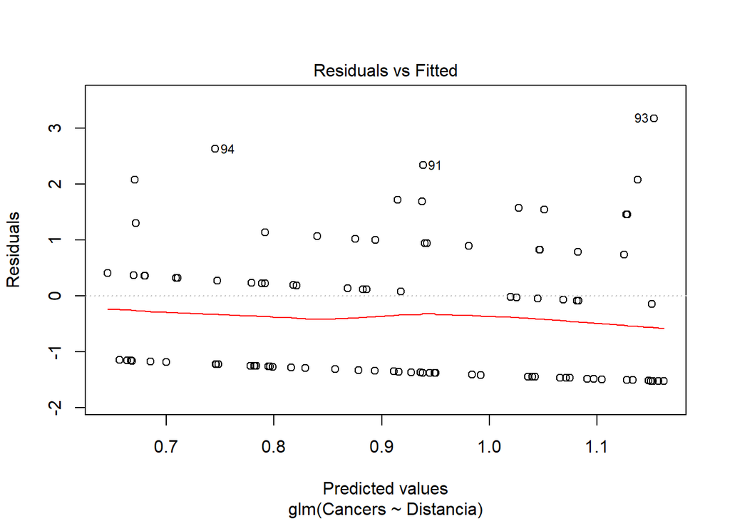

```r
plot(m2,1)
```

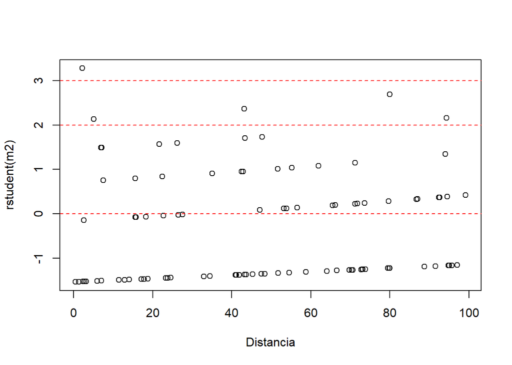

```r
plot(rstudent(m2)~Distancia,dd)
abline(h=c(-3,-2,0,2,3),lty=2,col="red")
```

*Sí hi ha sobre-dispersió. Model no vàlid encara que la gràfica de residuals suert raonablement bé.*

4. Pot aparèixer algun problema utilitzant aquest model?

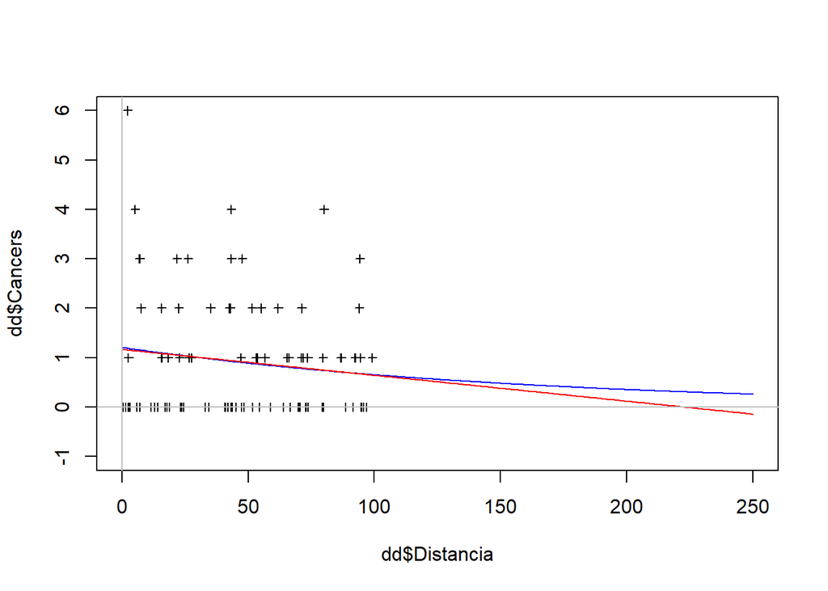

```r
plot(dd$Distancia,dd$Cancers,xlim=c(0,250),ylim=c(-1,6),pch=3,cex=.7)
lines(0:250,exp(coef(m1)[1]+coef(m1)[2]*(0:250)),col="blue")
lines(0:250,(coef(m2)[1]+coef(m2)[2]*(0:250)),col="red")
abline(h=0,col="grey")
abline(v=0,col="grey")
```

*Sí, el valor predit pot arribar a ser negatiu*

**d) Opcional. El mateix que en l’apartat b) però assumint que pot haver-hi sobredispersió o subdispersió.**

*i. Quina família de distribucions i quina funció link heu de considerar?*

*Familia quasipoisson i link=log*

*ii. La relació entre Cancers i Distancia és significativa amb un nivell del 10%?*

```r
mq<-glm(Cancers~Distancia,family=quasipoisson(link=log),data=dd)
summary(mq)
```

```
##
## Call:
## glm(formula = Cancers ~ Distancia, family = quasipoisson(link = log),
##     data = dd)
##
## Deviance Residuals:
##     Min       1Q   Median       3Q      Max
## -1.5504  -1.3491  -1.1553   0.3877   3.1304
##
## Coefficients:
##              Estimate Std. Error t value Pr(>|t|)
## (Intercept)  0.186865   0.235364   0.794    0.429
## Distancia   -0.006138   0.004573  -1.342    0.183
##
## (Dispersion parameter for quasipoisson family taken to be 1.555271)
##
##     Null deviance: 149.48  on 93  degrees of freedom
## Residual deviance: 146.64  on 92  degrees of freedom
## AIC: NA
##
## Number of Fisher Scoring iterations: 5
```

*No és significatiu. El paràmetre de dispersió és el que haviem calculat a l’apartat b).*